# Clustering Homework

```r
library(tidyverse)
library(janitor)
library(broom)
library(factoextra)
```

# MVP

## 1. Explore Data

```r
mall_customers <- read_csv("data/mall_customers.csv") %>% clean_names()
mall_customers
```

| customer_id | gender | age | annual_income_k | spending_score_1_100 |
| --- | --- | --- | --- | --- |
| 1 | Male | 19 | 15 | 39 |
| 2 | Male | 21 | 15 | 81 |
| 3 | Female | 20 | 16 | 6 |
| 4 | Female | 23 | 16 | 77 |
| 5 | Female | 31 | 17 | 40 |
| 6 | Female | 22 | 17 | 76 |
| 7 | Female | 35 | 18 | 6 |
| 8 | Female | 23 | 18 | 94 |
| 9 | Male | 64 | 19 | 3 |
| 10 | Female | 30 | 19 | 72 |

[output cut: 190 more lines]

there are 2 non-numerical columns: customerID and gender k means method uses numerical data remove CustomerID column and gender column will most likely be irrelevant

```r
mall_customers_numerical <- mall_customers %>%
  select(-customer_id, -gender)
```

Visualise variables in question (annual income and spending score)

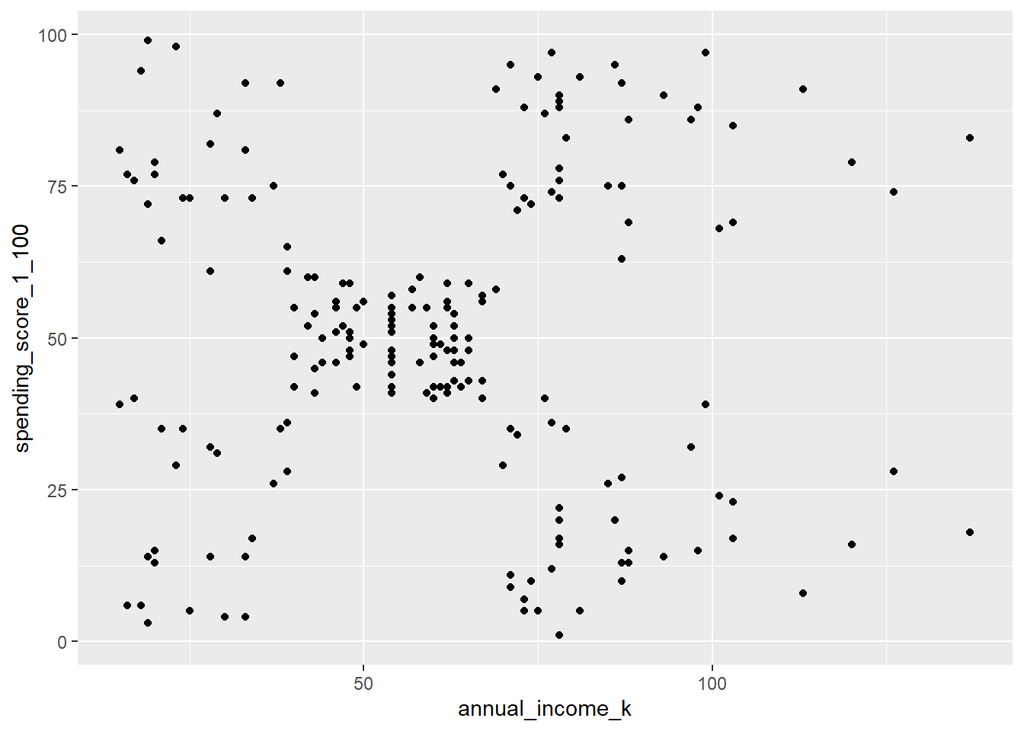

```r
mall_customers_numerical %>%
  ggplot(aes(x = annual_income_k, y = spending_score_1_100)) +
  geom_point()
```

It does look like there are some potential groups so this data would be appropriate for clustering You can see one very ‘tight’ cluster around 50,50, surrounded by 4 ‘looser’ clusters

## 2.

### Scaling

First, check what we currently have for mean and SD in the two variables

```r
mall_customers_numerical %>%
  as_tibble() %>%
  pivot_longer(cols = c("annual_income_k", "spending_score_1_100"),
               names_to = "data_category",
               values_to = "value") %>%
  group_by(data_category) %>%
  summarise(mean = round(mean(value)),
            sd = sd(value))
```

| data_category | mean | sd |
| --- | --- | --- |
| annual_income_k | 61 | 26.26472 |
| spending_score_1_100 | 50 | 25.82352 |

We need the data to be scaled so that the mean is 0 and the sd is one

```r
(mall_scale <- mall_customers_numerical %>%
   select(annual_income_k, spending_score_1_100) %>%
    mutate(across(everything(),
         .fns = scale))
)
```

| annual_income_k | spending_score_1_100 |
| --- | --- |
| -1.73464625 | -0.433713114 |
| -1.73464625 | 1.192711064 |
| -1.69657236 | -1.711617825 |
| -1.69657236 | 1.037813523 |
| -1.65849848 | -0.394988729 |
| -1.65849848 | 0.999089138 |
| -1.62042459 | -1.711617825 |
| -1.62042459 | 1.696128071 |
| -1.58235070 | -1.827790981 |
| -1.58235070 | 0.844191597 |

[output cut: 190 more lines]

Check scaled mean and sd are 0 and 1:

```r
mall_scale %>%
  as_tibble() %>%
  pivot_longer(cols = c("annual_income_k", "spending_score_1_100"),
               names_to = "data_category",
               values_to = "value") %>%
  group_by(data_category) %>%
  summarise(mean = round(mean(value)),
            sd = sd(value))
```

| data_category | mean | sd |
| --- | --- | --- |
| annual_income_k | 0 | 1 |
| spending_score_1_100 | 0 | 1 |

### Clustering

```r
(clustered_mall <- kmeans(x = mall_scale,
                         centers = 5,
                         nstart = 25)
)
```

```
## K-means clustering with 5 clusters of sizes 22, 23, 39, 35, 81
##
## Cluster means:
##   annual_income_k spending_score_1_100
## 1      -1.3262173           1.12934389
## 2      -1.3042458          -1.13411939
## 3       0.9891010           1.23640011
## 4       1.0523622          -1.28122394
## 5      -0.2004097          -0.02638995
##
## Clustering vector:
##   [1] 2 1 2 1 2 1 2 1 2 1 2 1 2 1 2 1 2 1 2 1 2 1 2 1 2 1 2 1 2 1 2 1 2 1 2 1 2
##  [38] 1 2 1 2 1 2 5 2 1 5 5 5 5 5 5 5 5 5 5 5 5 5 5 5 5 5 5 5 5 5 5 5 5 5 5 5 5
##  [75] 5 5 5 5 5 5 5 5 5 5 5 5 5 5 5 5 5 5 5 5 5 5 5 5 5 5 5 5 5 5 5 5 5 5 5 5 5
## [112] 5 5 5 5 5 5 5 5 5 5 5 5 3 4 3 5 3 4 3 4 3 5 3 4 3 4 3 4 3 4 3 5 3 4 3 4 3
## [149] 4 3 4 3 4 3 4 3 4 3 4 3 4 3 4 3 4 3 4 3 4 3 4 3 4 3 4 3 4 3 4 3 4 3 4 3 4
## [186] 3 4 3 4 3 4 3 4 3 4 3 4 3 4 3
##
## Within cluster sum of squares by cluster:
## [1]  5.217630  7.577407 19.655252 18.304646 14.485632
##  (between_SS / total_SS =  83.6 %)
##
## Available components:
##
## [1] "cluster"      "centers"      "totss"        "withinss"     "tot.withinss"
## [6] "betweenss"    "size"         "iter"         "ifault"
```

```r
min_k <- 1
max_k <- 20

k_clusters <- tibble(k = min_k:max_k) %>%
  mutate(
    kclust = map(k, ~kmeans(mall_scale, .x, nstart = 25)),
    tidied = map(kclust, tidy),
    glanced = map(kclust, glance),
    augmented = map(kclust, augment, mall_customers_numerical)
  )

k_clusters
```

| k | kclust | tidied | glanced | augmented |
| --- | --- | --- | --- | --- |
| 1 |  |  |  |  |
| 2 |  |  |  |  |
| 3 |  |  |  |  |
| 4 |  |  |  |  |
| 5 |  |  |  |  |
| 6 |  |  |  |  |
| 7 |  |  |  |  |
| 8 |  |  |  |  |
| 9 |  |  |  |  |
| 10 |  |  |  |  |

[output cut: 10 more lines]

```r
(clusterings <- k_clusters %>%
  unnest(glanced)
)
```

| k | kclust | tidied | totss | tot.withinss | betweenss | iter | augmented |
| --- | --- | --- | --- | --- | --- | --- | --- |
| 1 |  |  | 398 | 398.00000 | -2.273737e-13 | 1 |  |
| 2 |  |  | 398 | 267.67171 | 1.303283e+02 | 1 |  |
| 3 |  |  | 398 | 156.91549 | 2.410845e+02 | 2 |  |
| 4 |  |  | 398 | 108.37671 | 2.896233e+02 | 3 |  |
| 5 |  |  | 398 | 65.24057 | 3.327594e+02 | 4 |  |
| 6 |  |  | 398 | 54.78206 | 3.432179e+02 | 2 |  |
| 7 |  |  | 398 | 44.64043 | 3.533596e+02 | 3 |  |
| 8 |  |  | 398 | 36.96238 | 3.610376e+02 | 3 |  |
| 9 |  |  | 398 | 32.19843 | 3.658016e+02 | 3 |  |
| 10 |  |  | 398 | 28.94512 | 3.690549e+02 | 3 |  |

[output cut: 10 more lines]

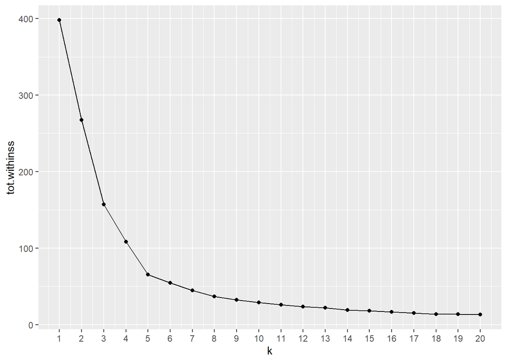

```r
clusterings %>%
  ggplot(aes(x = k, y = tot.withinss)) +
  geom_point() +
  geom_line() +
  scale_x_continuous(breaks = seq(1, 20, by = 1))
```

There is a kink at 3 and at 5, check this with fviz ‘silhouette’

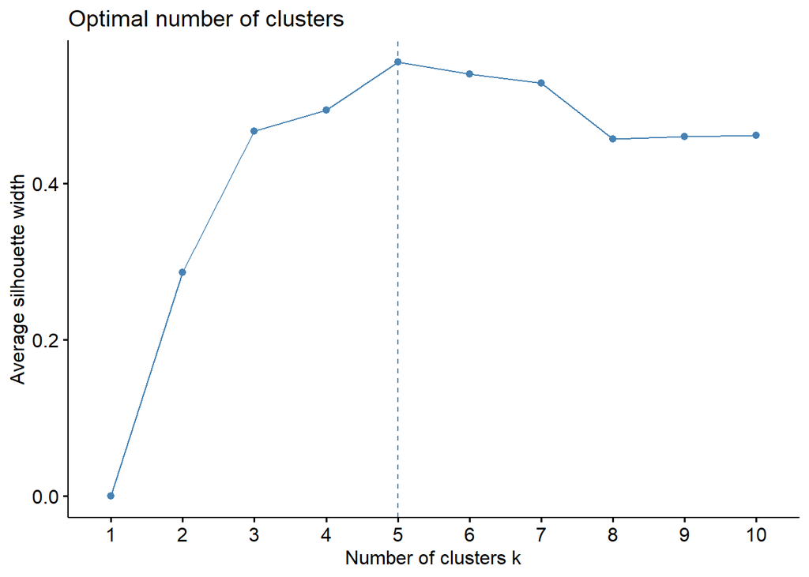

```r
fviz_nbclust(mall_scale,
             kmeans,
             method = "silhouette",
             nstart = 25)
```

A value of k = 5 is the best fit

## 3. Visualise clustering with k = 5

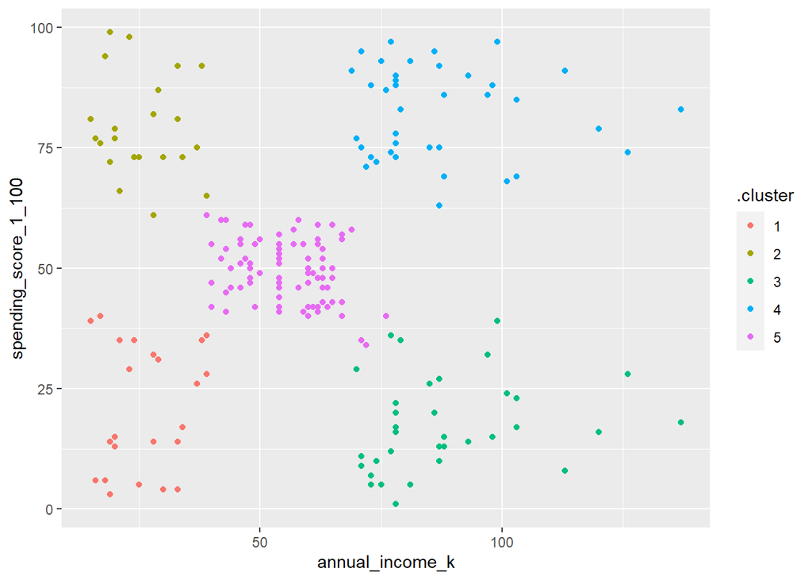

```r
clusterings %>%
  unnest(cols = c(augmented)) %>%
  filter(k == 5) %>%
  ggplot(aes(x = annual_income_k, y = spending_score_1_100)) +
  geom_point(aes(colour = .cluster))
```

## 4. Does the clustering seem like a good fit for this data?

Check mean for each cluster

```r
clusterings %>%
  unnest(augmented) %>%
  filter(k == 5) %>%
  group_by(.cluster) %>%
  summarise(mean(annual_income_k), mean(spending_score_1_100))
```

| .cluster | mean(annual_income_k) | mean(spending_score_1_100) |
| --- | --- | --- |
| 1 | 26.30435 | 20.91304 |
| 2 | 25.72727 | 79.36364 |
| 3 | 88.20000 | 17.11429 |
| 4 | 86.53846 | 82.12821 |
| 5 | 55.29630 | 49.51852 |

## 5. Cluster Attributes

Assuming that a high spending score indicates that the customer spends a lot of money in the mall: